# **Econometric Models in Practice**

### 9.11.8 FEVD

[figure not shown]

```r
suppressPackageStartupMessages(library(vars))

# FEVD
fevd_obj <- fevd(m, n.ahead = 12)

# Reset state grafis dan longgarkan margin
op <- par(no.readonly = TRUE)
on.exit(par(op), add = TRUE)
par(mfrow = c(1,1), mar = c(4.5, 4.5, 2, 1), oma = c(0,0,0,0))

plot(fevd_obj)  # base plotting milik paket vars
```

### 9.11.9 Peramalan

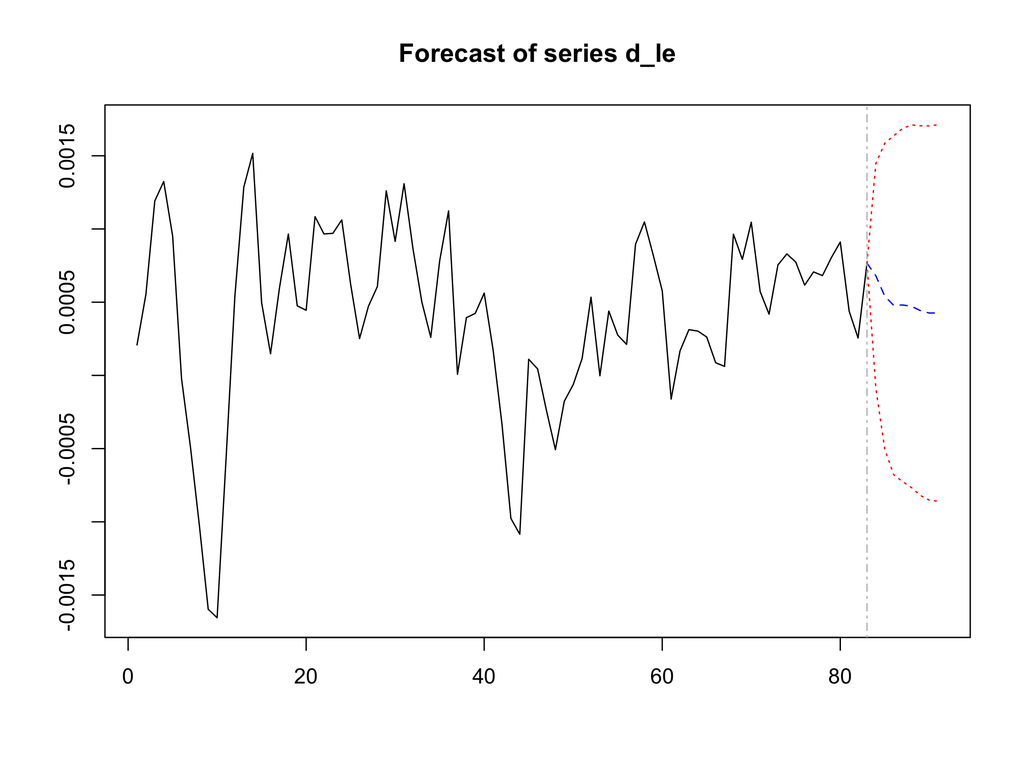

```r
fc <- predict(var_mod, n.ahead = 8, ci = 0.95)
# Plot untuk satu seri contoh
plot(fc, names = "d_le")
```

## 9.12 Catatan Praktik & Tips

- Skala & transformasi penting: *stabilkan varians* (log), buat stasioner (diff atau gunakan VECM bila kointegrasi).
- Periksa sensitivitas terhadap pemilihan lag dan urutan variabel (untuk IRF berbasis Cholesky).
- Untuk **SVAR** (restriksi struktural berbasis teori), lihat paket `svars`/`vars::SVAR`.
- Jangan lupa cek *overfitting*: VAR mudah “lapar parameter” (\(K^2p\) koefisien + konstanta).

## 9.13 Ringkasan Satu

VAR memodelkan interaksi dinamis multi‑variabel secara fleksibel. Estimasi mudah (OLS per persamaan), evaluasi pakai uji serial correlation/normalitas/ARCH, stabilitas via akar. Kegunaan utama: IRF, FEVD, peramalan. Saat ada kointegrasi, beralih ke VECM dan/atau **SVAR** untuk interpretasi struktural.

# 10 Ringkasan Model

| Model | Fokus Analisis | Asumsi Kunci | Kegunaan Utama |
| --- | --- | --- | --- |
| OLS | Hubungan linier rata-rata | Eksogenitas, homoskedastisitas | Cross‑section & baseline |
| IV | Kausalitas dgn endogenitas | Instrumen relevan & valid | Causal inference |
| FE (Panel) | Kontrol heterogenitas tetap | Efek tetap konstan per unit | Panel data |
| DiD | Evaluasi kebijakan | Parallel trends | Eksperimen alami |
| Synthetic Control | Unit sintetik pembanding | *Good pre‑treatment fit* | Studi kebijakan per-unit |
| VAR | Dinamika multivariat | (Kira‑)stasioneritas | Makro/keuangan/DERET waktu |

> Untuk komputasi dapat dicek di link: https://project25.shinyapps.io/ekonometrika/

# 11 **Tugas Akhir Mata Kuliah: Analisis Model Ekonometrika**

## 11.1 **Tujuan**

Mahasiswa mampu menerapkan salah satu model ekonometrika atau deret waktu yang telah dipelajari (misalnya Data Penel, DiD, SCM, dan VAR) menggunakan **data nyata (real data)** untuk menghasilkan analisis yang ilmiah dan aplikatif.

## 11.2 **Deskripsi Tugas**

1. Mahasiswa menyusun **makalah ilmiah** (format seperti artikel jurnal) berdasarkan model pilihan masing-masing.
2. Mahasiswa **bebas memilih topik**, **model**, dan **sumber data** (minimal 30 observasi atau 10 tahun periode).
3. Analisis harus mencakup:
   - Pemilihan dan deskripsi data (sumber data resmi atau publik seperti BPS, World Bank, BMKG, BI, Kaggle, dsb);
   - Penjelasan model yang digunakan (lengkap dengan formulasi matematis dan asumsi);
   - Estimasi dan interpretasi hasil;
   - Uji diagnostik dan validitas model;
   - Kesimpulan dan implikasi kebijakan/praktis.

## 11.3 **Struktur Makalah**

### 11.3.1 1. Pendahuluan

- Latar belakang masalah
- Rumusan masalah dan tujuan penelitian
- Relevansi teoritis dan empiris

### 11.3.2 2. Tinjauan Pustaka dan Model

- Ringkasan teori dan literatur terkait
- Penjelasan model (misalnya Data Panel, DiD, SCM, VAR)
- Formulasi matematis dan asumsi dasar

### 11.3.3 3. Metodologi

- Sumber data dan variabel yang digunakan
- Proses transformasi data dan uji stasioneritas (bila perlu)
- Estimasi model, uji diagnostik, serta langkah-langkah teknis

### 11.3.4 4. Hasil dan Pembahasan

- Hasil estimasi utama (tabel/plot)
- Interpretasi ekonometrik/statistik
- Pembahasan implikasi dari hasil model

### 11.3.5 5. Kesimpulan dan Rekomendasi

- Ringkasan hasil utama
- Rekomendasi kebijakan atau riset lanjutan

### 11.3.6 6. Daftar Pustaka

- Minimal 5 referensi ilmiah (jurnal, buku teks, atau dokumen resmi)

## 11.4 **Kriteria Penilaian**

| Komponen | Bobot |
| --- | --- |
| Kesesuaian topik dan data nyata | 20% |
| Kejelasan model dan formulasi matematis | 25% |
| Kualitas analisis dan interpretasi hasil | 30% |
| Ketepatan uji dan validasi model | 15% |
| Kerapian penulisan dan referensi | 10% |

## 11.5 **Format Penulisan**

- Format makalah: `.docx` atau `.Rmd`
- Panjang: 8–12 halaman (tidak termasuk lampiran dan daftar pustaka)
- Font: Times New Roman 12 pt, spasi 1.5
- Grafik/tabel dapat dibuat menggunakan **R**, **Python**, atau software lain
- Gunakan gaya kutipan APA atau IEEE

## 11.6 **Contoh Topik**

- Pengaruh inflasi dan suku bunga terhadap pertumbuhan ekonomi Indonesia (VAR)
- Kausalitas antara PM2.5 dan suhu udara (VAR atau VECM)
- Dampak kebijakan PPKM terhadap mobilitas penduduk (Difference-in-Differences)
- Analisis IRF dan FEVD pada model VAR untuk hubungan konsumsi dan investasi
- Synthetic Control untuk efek kebijakan subsidi atau cukai

## 11.7 **Petunjuk Pengumpulan**

- Kumpulkan dalam bentuk file `.Rmd` dan hasil **render (HTML atau PDF)**.
- Lampirkan dataset asli (CSV/XLSX) dan skrip R/Python (jika terpisah).
- Pastikan file dapat dijalankan ulang tanpa error (*reproducible*).
- Tugas Akhir dikumpulan pada link gform berikut (1 Desember 2025 Pukul 16:00 WIB): https://forms.gle/QEwdZz6smK9eW3Jb8

# 12 Referensi Singkat

## 12.1 Dasar Ekonometrika dan Panel Data

- Wooldridge, J. M. (2010). *Econometric Analysis of Cross Section and Panel Data* (2nd ed.). MIT Press.
- Angrist, J. D., & Pischke, J.-S. (2009). *Mostly Harmless Econometrics: An Empiricist’s Companion*. Princeton University Press.

## 12.2 Metode Synthetic Control (SCM)

- Abadie, A., Diamond, A., & Hainmueller, J. (2010). Synthetic control methods for comparative case studies: Estimating the effect of California’s tobacco control program. *Journal of the American Statistical Association*, 105(490), 493–505. https://doi.org/10.1198/jasa.2009.ap08746
- Abadie, A. (2021). *Using Synthetic Controls: Methods and Practice*. Cambridge University Press.
- Ben-Michael, E., Feller, A., & Rothstein, J. (2021). The augmented synthetic control method. *Journal of the American Statistical Association*, 116(536), 1789–1803. https://doi.org/10.1080/01621459.2021.1929245

## 12.3 Perluasan SCM dan Panel Dinamis (DiD & Event Study)

- Imai, K., & Kim, I. S. (2021). On the use of two-way fixed effects models for causal inference with heterogeneous treatment effects. *American Journal of Political Science*, 65(3), 849–866. https://doi.org/10.1111/ajps.12674
- Callaway, B., & Sant’Anna, P. H. C. (2021). Difference-in-differences with multiple time periods. *Journal of Econometrics*, 225(2), 200–230. https://doi.org/10.1016/j.jeconom.2020.12.001
- Sun, L., & Abraham, S. (2021). Estimating dynamic treatment effects in event studies with heterogeneous treatment effects. *Journal of Econometrics*, 225(2), 175–199. https://doi.org/10.1016/j.jeconom.2020.09.006
- Lütkepohl, H. (2005). *New Introduction to Multiple Time Series Analysis*. Springer.

## 12.4 VAR

- Lütkepohl, H. (2005). *New Introduction to Multiple Time Series Analysis*. Springer.
- Kilian, L., & Lütkepohl, H. (2017). *Structural Vector Autoregressive Analysis*. Cambridge University Press.
- Pfaff, B. (2008). *VAR, SVAR and SVEC Models: Implementation Within R Package vars*. *Journal of Statistical Software*, 27(4).
- Stock, J. H., & Watson, M. W. (2001). *Vector Autoregressions*. *Journal of Economic Perspectives*, 15(4), 101–115.